# Confirmatory Factor Analysis: Satisfaction of Self

by JUMEX365

## Data loaging + Packages

```r
library(dplyr)
library(psych)
library(sjPlot)
library(lavaan)
library(EFA.dimensions)

data(data_RSE)
dataset <- data.frame(data_RSE)
```

## Deleting NA variables + Distribution

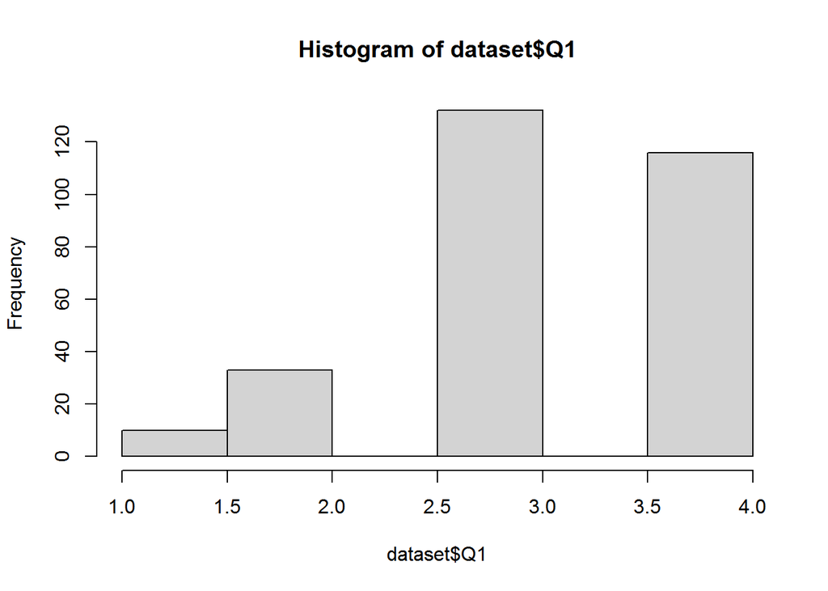

```r
dataset <- filter(dataset, Q1 > 0, Q2 > 0, Q3 > 0, Q4 > 0, Q5 > 0, Q6 > 0, Q7 > 0, Q8 > 0, Q9 > 0, Q10 > 0)
hist(dataset$Q1)
```

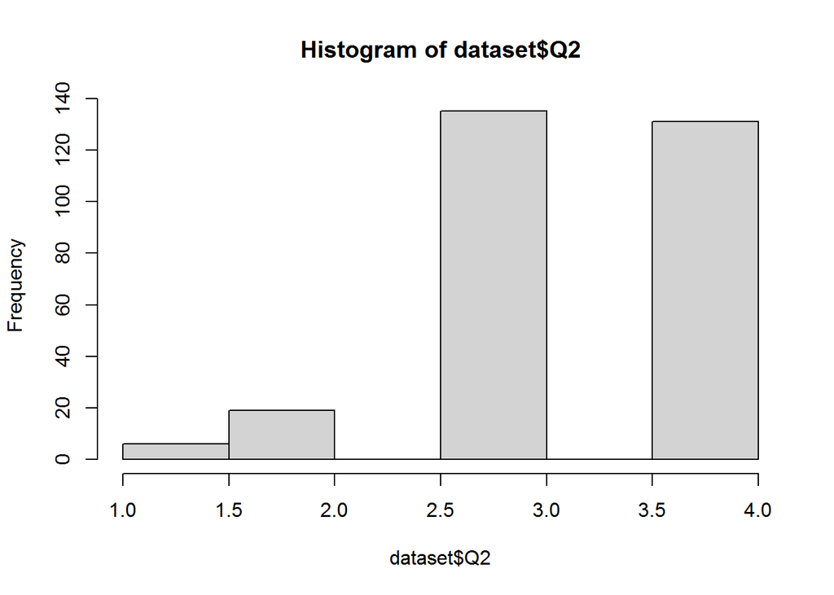

```r
hist(dataset$Q2)
```

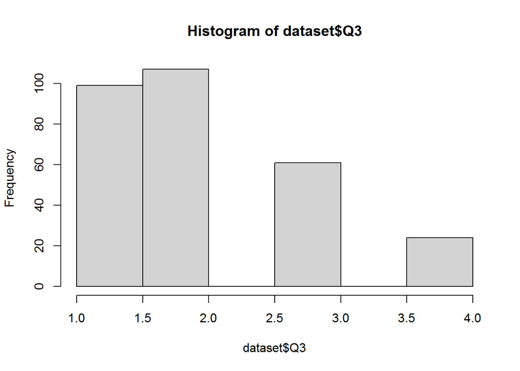

```r
hist(dataset$Q3)
```

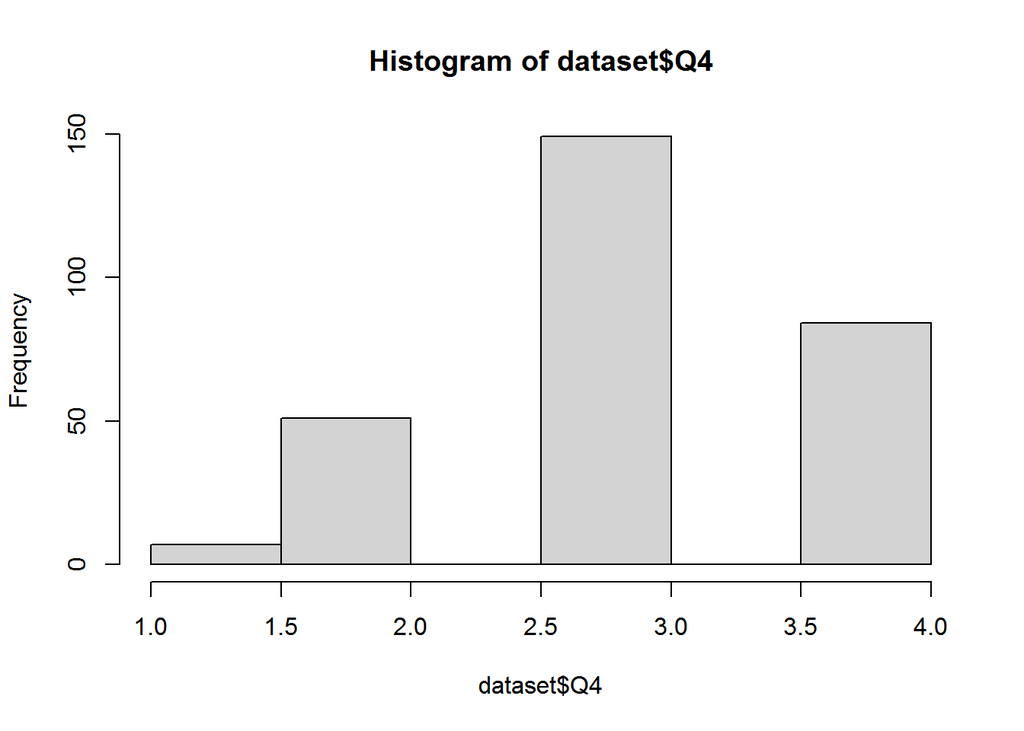

```r
hist(dataset$Q4)
```

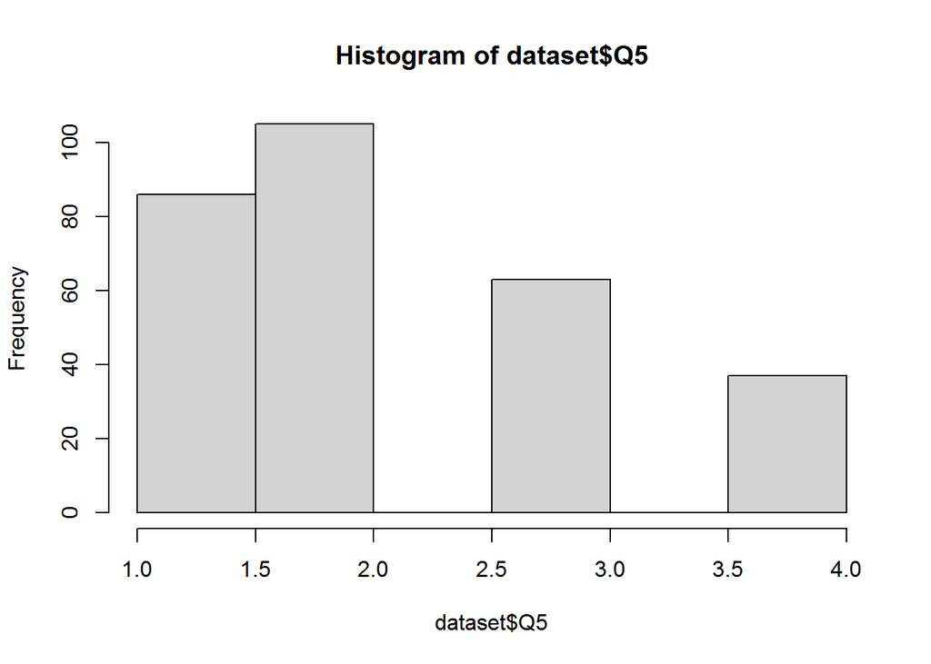

```r
hist(dataset$Q5)
```

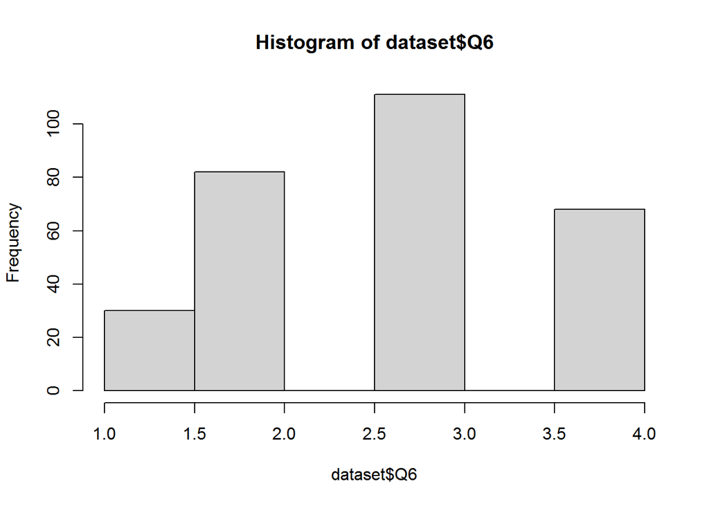

```r
hist(dataset$Q6)
```

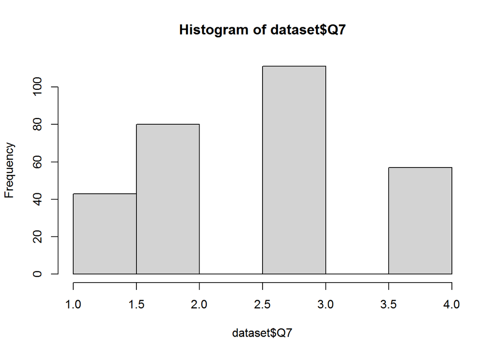

```r
hist(dataset$Q7)
```

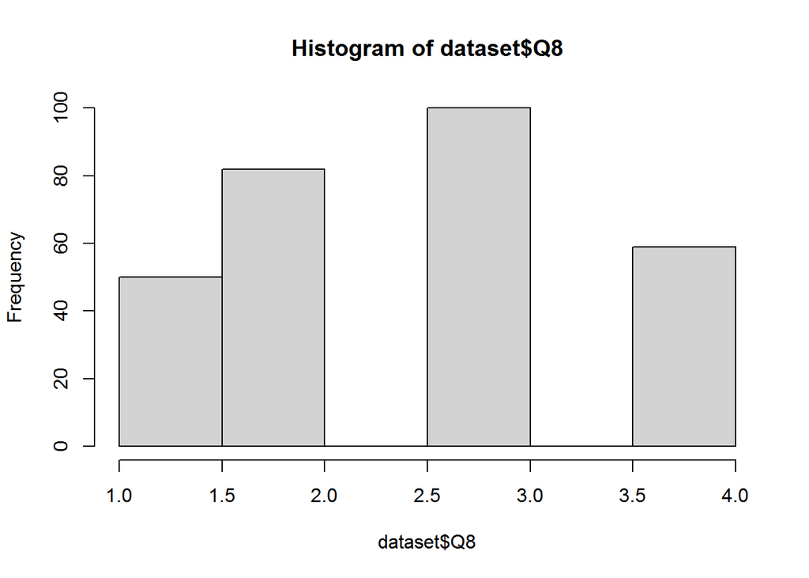

```r
hist(dataset$Q8)
```

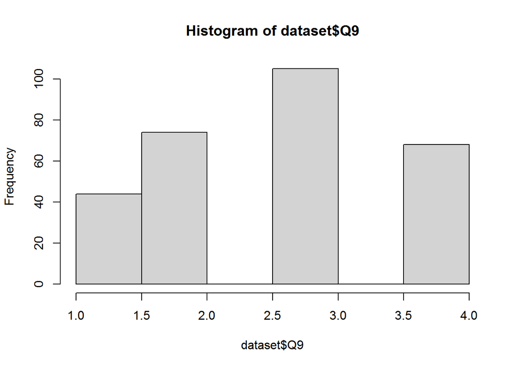

```r
hist(dataset$Q9)
```

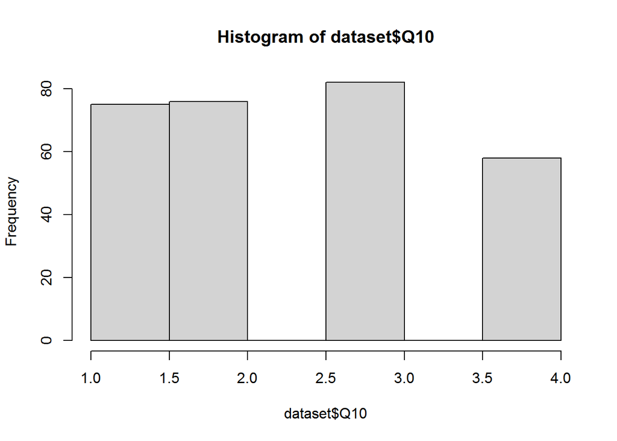

```r
hist(dataset$Q10)
```

Now distribution is fine.

## Theoretical assumption

The factor should measure satisfaction of self.

From description it seems to me that all the questions measure satisfaction of self (based on positive or negative scale), so I include them all to one factor.

## CFA_1

```r
model_1 <- '
Satisofself =~ Q1 + Q2 + Q3 + Q4 + Q5 + Q6 + Q7 + Q8 + Q9 + Q10
'
```

```r
CFAmod_1 <- cfa(model_1, data = dataset)
summary(CFAmod_1, fit.measures = TRUE)
```

```
## lavaan 0.6-11 ended normally after 28 iterations
##
##   Estimator                                         ML
##   Optimization method                           NLMINB
##   Number of model parameters                        20
##
##   Number of observations                           291
##
## Model Test User Model:
##
##   Test statistic                               183.056
##   Degrees of freedom                                35
##   P-value (Chi-square)                           0.000
##
## Model Test Baseline Model:
##
##   Test statistic                              1921.785
##   Degrees of freedom                                45
##   P-value                                        0.000
##
## User Model versus Baseline Model:
##
##   Comparative Fit Index (CFI)                    0.921
##   Tucker-Lewis Index (TLI)                       0.899
##
## Loglikelihood and Information Criteria:
##
##   Loglikelihood user model (H0)              -2958.830
##   Loglikelihood unrestricted model (H1)      -2867.302
##
##   Akaike (AIC)                                5957.661
##   Bayesian (BIC)                              6031.127
##   Sample-size adjusted Bayesian (BIC)         5967.703
##
## Root Mean Square Error of Approximation:
##
##   RMSEA                                          0.121
##   90 Percent confidence interval - lower         0.104
##   90 Percent confidence interval - upper         0.138
##   P-value RMSEA <= 0.05                          0.000
```

[output cut: 23 more lines]

```
##     Q10              -1.581    0.132  -11.982    0.000
##
## Variances:
##                    Estimate  Std.Err  z-value  P(>|z|)
##    .Q1                0.328    0.029   11.378    0.000
##    .Q2                0.256    0.023   11.351    0.000
##    .Q3                0.285    0.028   10.355    0.000
##    .Q4                0.334    0.029   11.522    0.000
##    .Q5                0.433    0.039   11.008    0.000
##    .Q6                0.239    0.024    9.921    0.000
##    .Q7                0.265    0.026   10.028    0.000
##    .Q8                0.534    0.047   11.361    0.000
##    .Q9                0.366    0.034   10.667    0.000
##    .Q10               0.471    0.043   10.868    0.000
##     Satisofself       0.275    0.043    6.391    0.000
```

- Comparative Fit Index = 0.921 (<0.95). Result under threshold. Not really good.
- Tucker-Lewis Index = 0.899 (<0.95). Result under threshold. Not really good as well.
- RMSEA = 0.121 (> 0.08). Result more than threshold also bad.
- SRMR = 0.050 (< 0.08). Fine.

Overall model is not perfect. It is possible to improve it.

## CFA_1_MOD

```r
mi <- modindices(CFAmod_1)
mi[mi$op == "~~" & mi$mi >10, c(1:5)]
```

```
##    lhs op rhs     mi   epc
## 22  Q1 ~~  Q2 29.697 0.099
## 24  Q1 ~~  Q4 10.264 0.066
## 29  Q1 ~~  Q9 13.692 0.083
## 30  Q1 ~~ Q10 17.799 0.107
## 32  Q2 ~~  Q4 12.601 0.065
## 36  Q2 ~~  Q8 20.039 0.104
## 57  Q6 ~~  Q7 29.739 0.104
## 66  Q9 ~~ Q10 31.035 0.155
```

Epc <0.2 Optimal threshold of mi = 3.84, but it is necessary to take higher threshold = 10 (in order to maintain low chi-squared <0.05).

```r
model_1_2 <- '
Satisofself =~ Q1 + Q2 + Q3 + Q4 + Q5 + Q6 + Q7 + Q8 + Q9 + Q10
Q1 ~~ Q2
Q1 ~~ Q4
Q1 ~~ Q9
Q1 ~~ Q10
Q2 ~~ Q4
Q2 ~~ Q8
Q6 ~~ Q7
Q9 ~~ Q10
'
```

```r
CFAmod_1_2 <- cfa(model_1_2, data = dataset)
summary(CFAmod_1_2, fit.measures = TRUE)
```

```
## lavaan 0.6-11 ended normally after 39 iterations
##
##   Estimator                                         ML
##   Optimization method                           NLMINB
##   Number of model parameters                        28
##
##   Number of observations                           291
##
## Model Test User Model:
##
##   Test statistic                                43.262
##   Degrees of freedom                                27
##   P-value (Chi-square)                           0.025
##
## Model Test Baseline Model:
##
##   Test statistic                              1921.785
##   Degrees of freedom                                45
##   P-value                                        0.000
##
## User Model versus Baseline Model:
##
##   Comparative Fit Index (CFI)                    0.991
##   Tucker-Lewis Index (TLI)                       0.986
##
## Loglikelihood and Information Criteria:
##
##   Loglikelihood user model (H0)              -2888.934
##   Loglikelihood unrestricted model (H1)      -2867.302
##
##   Akaike (AIC)                                5833.867
##   Bayesian (BIC)                              5936.720
##   Sample-size adjusted Bayesian (BIC)         5847.926
##
## Root Mean Square Error of Approximation:
##
##   RMSEA                                          0.045
##   90 Percent confidence interval - lower         0.017
##   90 Percent confidence interval - upper         0.070
##   P-value RMSEA <= 0.05                          0.589
```

[output cut: 38 more lines]

```
##    .Q10               0.114    0.030    3.735    0.000
##
## Variances:
##                    Estimate  Std.Err  z-value  P(>|z|)
##    .Q1                0.307    0.029   10.683    0.000
##    .Q2                0.258    0.023   11.033    0.000
##    .Q3                0.278    0.028   10.016    0.000
##    .Q4                0.348    0.031   11.378    0.000
##    .Q5                0.422    0.039   10.804    0.000
##    .Q6                0.279    0.028    9.914    0.000
##    .Q7                0.306    0.031    9.982    0.000
##    .Q8                0.509    0.046   11.134    0.000
##    .Q9                0.366    0.036   10.155    0.000
##    .Q10               0.462    0.045   10.346    0.000
##     Satisofself       0.291    0.045    6.524    0.000
```

chi-squared is <0.05.

There is an improvement.

So, now model fits theoretical assumption.

## CFA_2

Deleting some questions to improve key indicators. Another way of improvement (as was mentioned in description of task).

```r
model_2 <- '
Satisofself =~ Q2 + Q3 + Q4 + Q5 + Q7 + Q10
'
```

```r
mi <- modindices(CFAmod_1)
mi[mi$op == "~~" & mi$mi >10, c(1:5)]
```

```
##    lhs op rhs     mi   epc
## 22  Q1 ~~  Q2 29.697 0.099
## 24  Q1 ~~  Q4 10.264 0.066
## 29  Q1 ~~  Q9 13.692 0.083
## 30  Q1 ~~ Q10 17.799 0.107
## 32  Q2 ~~  Q4 12.601 0.065
## 36  Q2 ~~  Q8 20.039 0.104
## 57  Q6 ~~  Q7 29.739 0.104
## 66  Q9 ~~ Q10 31.035 0.155
```

```r
CFAmod_2 <- cfa(model_2, data = dataset)
summary(CFAmod_2, fit.measures = TRUE)
```

```
## lavaan 0.6-11 ended normally after 23 iterations
##
##   Estimator                                         ML
##   Optimization method                           NLMINB
##   Number of model parameters                        12
##
##   Number of observations                           291
##
## Model Test User Model:
##
##   Test statistic                                22.137
##   Degrees of freedom                                 9
##   P-value (Chi-square)                           0.008
##
## Model Test Baseline Model:
##
##   Test statistic                               882.609
##   Degrees of freedom                                15
##   P-value                                        0.000
##
## User Model versus Baseline Model:
##
##   Comparative Fit Index (CFI)                    0.985
##   Tucker-Lewis Index (TLI)                       0.975
##
## Loglikelihood and Information Criteria:
##
##   Loglikelihood user model (H0)              -1844.107
##   Loglikelihood unrestricted model (H1)      -1833.038
##
##   Akaike (AIC)                                3712.214
##   Bayesian (BIC)                              3756.294
##   Sample-size adjusted Bayesian (BIC)         3718.239
##
## Root Mean Square Error of Approximation:
##
##   RMSEA                                          0.071
##   90 Percent confidence interval - lower         0.034
##   90 Percent confidence interval - upper         0.109
##   P-value RMSEA <= 0.05                          0.156
```

[output cut: 15 more lines]

```
##     Q3               -1.667    0.128  -13.055    0.000
##     Q4                0.973    0.099    9.870    0.000
##     Q5               -1.576    0.133  -11.812    0.000
##     Q7                1.625    0.130   12.532    0.000
##     Q10              -1.699    0.144  -11.777    0.000
##
## Variances:
##                    Estimate  Std.Err  z-value  P(>|z|)
##    .Q2                0.250    0.023   10.792    0.000
##    .Q3                0.239    0.029    8.315    0.000
##    .Q4                0.338    0.030   11.178    0.000
##    .Q5                0.418    0.041   10.165    0.000
##    .Q7                0.313    0.034    9.345    0.000
##    .Q10               0.493    0.048   10.195    0.000
##     Satisofself       0.230    0.036    6.486    0.000
```

- Comparative Fit Index = 0.985 (>0.95). Result more than threshold. Fine.
- Tucker-Lewis Index = 0.0.975 (>0.95). Result more than threshold. Ok as well.
- RMSEA = 0.071 (< 0.08). Good.
- SRMR = 0.031 (< 0.08). Fine.

Overall, all key indicators is even better than in model_1, but worse than in improved model_1_2.

So, now model fits theoretical assumption.

## Models comparison

```r
anova(CFAmod_1, CFAmod_1_2, CFAmod_2)
```

```
## Chi-Squared Difference Test
##
##            Df    AIC    BIC   Chisq Chisq diff Df diff Pr(>Chisq)
## CFAmod_2    9 3712.2 3756.3  22.137
## CFAmod_1_2 27 5833.9 5936.7  43.262     21.125      18     0.2732
## CFAmod_1   35 5957.7 6031.1 183.056    139.794       8     <2e-16 ***
## ---
## Signif. codes:  0 '***' 0.001 '**' 0.01 '*' 0.05 '.' 0.1 ' ' 1
```

However, AIC and BIC values are lower for CFAmod_2.

I cannot make visual representations of models, because “semPlot” and “semTools” crush my Rstudio.